# NFL_Combine_Project

Philip Booth

2024-05-6

## Introduction

Football is a cultural staple in the US. It ranks as the most highly broadcasted sport as well as the most played sport at a high-school and college level. This intense spotlight, in turn drives some fierce competition. At the top level, picking the right player to fit in your team can pay out dividends in the season. The NFL combine gives scouts supplementary data to help their organizations pick the best player for their teams? In this report, I’m interested in exploring NFL Combine metrics and their ability to predict NFL Success for Wide Receivers. In particular, I will observe whether a faster 3 cone drill is predictive of more yards per game.

## Summary Data

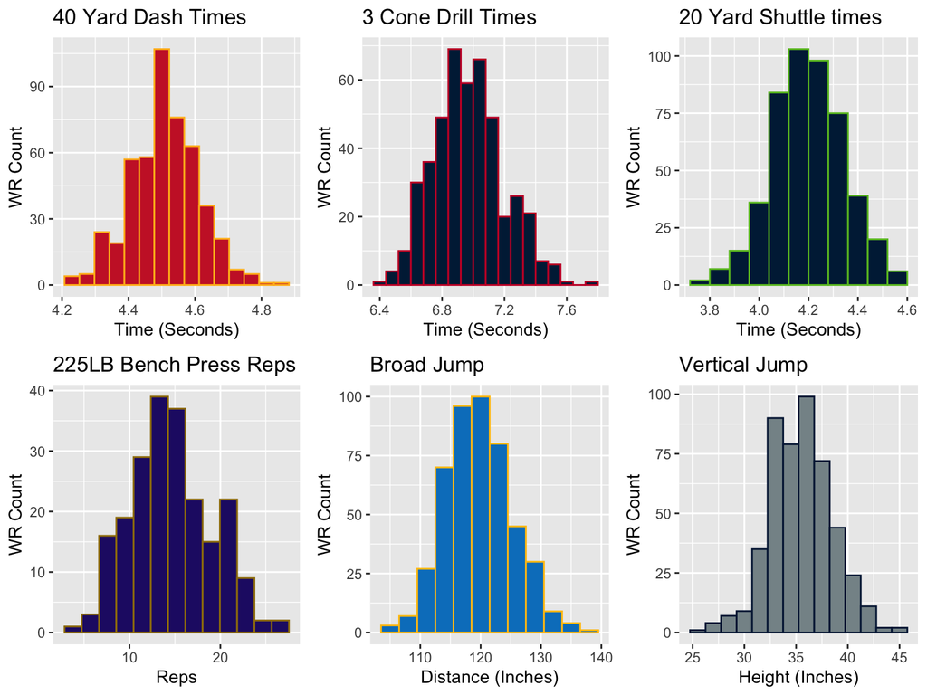

```r
#Distributions of the 40 yard dash, Bench Press and 3 Cone drill
w1 <- ggplot(WR_data, aes(x=X40yards)) + geom_histogram(binwidth = .045,col="#FFB81C", fill ="#CA2430") +
  ggtitle("40 Yard Dash Times ") + xlab("Time (Seconds)") + ylab("WR Count")

w2 <- ggplot(WR_data, aes(x=bench)) + geom_histogram(binwidth = 1.9,col="#9E7C0C", fill="#241773") +
  ggtitle("225LB Bench Press Reps") + xlab("Reps") + ylab("WR Count")

w3 <- ggplot(WR_data, aes(x=X3cone)) + geom_histogram(binwidth = .08,col="#C60C30", fill="#002244") +
  ggtitle("3 Cone Drill Times") + xlab("Time (Seconds)") + ylab("WR Count")

w4 <- ggplot(WR_data, aes(x=leap)) + geom_histogram(binwidth = 1.5,col="#041E42", fill="#869397") +
  ggtitle("Vertical Jump") + xlab("Height (Inches)") + ylab("WR Count")

w5 <- ggplot(WR_data, aes(x=jump)) + geom_histogram(binwidth = 3,col="#FFC20E", fill="#0080C6") +
 ggtitle("Broad Jump") + xlab("Distance (Inches)") + ylab("WR Count")

w6 <- ggplot(WR_data, aes(x=shuttle)) + geom_histogram(binwidth = .08,col="#69BE28", fill="#002244") +
  ggtitle("20 Yard Shuttle times") + xlab("Time (Seconds)") + ylab("WR Count")

#arrange multiple graphs together
grid.arrange(w1, w3, w6, w2, w5, w4, ncol = 3)
```

These 6 histograms illustrate the distributions of key metrics for the combine. Once again, I intend to find if there is a metric that predicts NFL success. From the publications I’ve read, it is evident that bench press has no effect on a players success in the league. I wanted to display the following scatter-plot so we could have a reference point when we compare other combine metrics that are more relevant to a wide receiver. The following data compare the number of yards per game as a function of bench press reps.

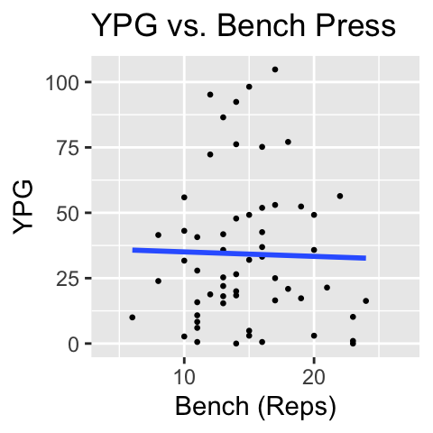

```r
 ggplot(WR_data, aes(x=bench, y=YPG)) + geom_point(size=.5) +
  stat_smooth(method= "lm", se=FALSE, formula = y ~ x, span=1) +
  ggtitle("YPG vs. Bench Press") + xlab("Bench (Reps)") + ylab("YPG")
```

Let’s move away from less relevant metrics and go back to everyone’s favorite test: the 40 yard dash. If popularity of the test correlated to success on the field, we’d have every team drooling over who they could draft from the elite group of speedsters that year. Let’s test whether there is a true correlation present there.

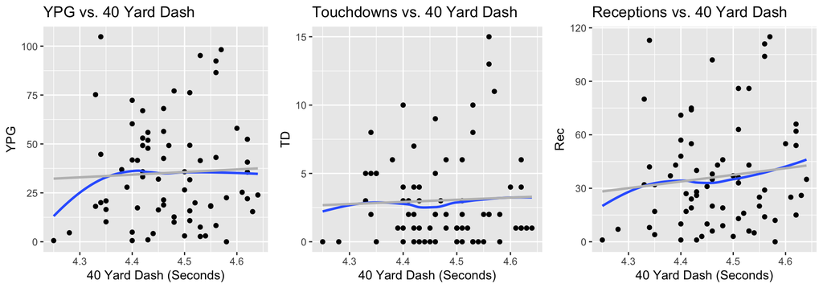

```r
#Scatter plot of yards as a function of 40 times

WR_40 <- WR_data %>%
  mutate(TD_adj = TD + .01) %>%
  filter(Gms >= 4)

g4 <- ggplot(WR_40, aes(x=X40yards, y=YPG)) + geom_point() +
  stat_smooth(method= "loess", se=FALSE, formula = y ~ x, span=1) +
  stat_smooth(method= "lm", se=FALSE, formula = y ~ x, col="grey") +
  ggtitle("YPG vs. 40 Yard Dash") + xlab("40 Yard Dash (Seconds)") + ylab("YPG")

g5 <- ggplot(WR_40, aes(x=X40yards, y=TD)) + geom_point() +
    stat_smooth(method= "loess", se=FALSE, formula = y ~ x, span=1) +
    stat_smooth(method= "lm", se=FALSE, formula = y ~ x, col="grey") +
    ggtitle("Touchdowns vs. 40 Yard Dash") + xlab("40 Yard Dash (Seconds)") + ylab("TD")

g6 <- ggplot(WR_40, aes(x=X40yards, y=Rec)) + geom_point() +
  stat_smooth(method= "loess", se=FALSE , formula = y ~ x, span=1) +
  stat_smooth(method= "lm", se=FALSE, formula = y ~ x, col="grey") +
  ggtitle("Receptions vs. 40 Yard Dash") + xlab("40 Yard Dash (Seconds)") + ylab("Rec")

grid.arrange(g4, g5, g6, ncol = 3)
```

### Re-expression

None of these scatter-plots, which measure statistical success through 40 times provide any immediate correlations, but the TD data looks skewed. In hopes that mitigating skewness would yield potential insights, I first used a box-plot to re-express the TD distribution making the plot as symmetric as possible. However, the resulting scatter-plot using re-expressed TD data still provided no definitive evidence in proving any correlation between performance and 40 yard dash times. I think I should try my luck elsewhere.

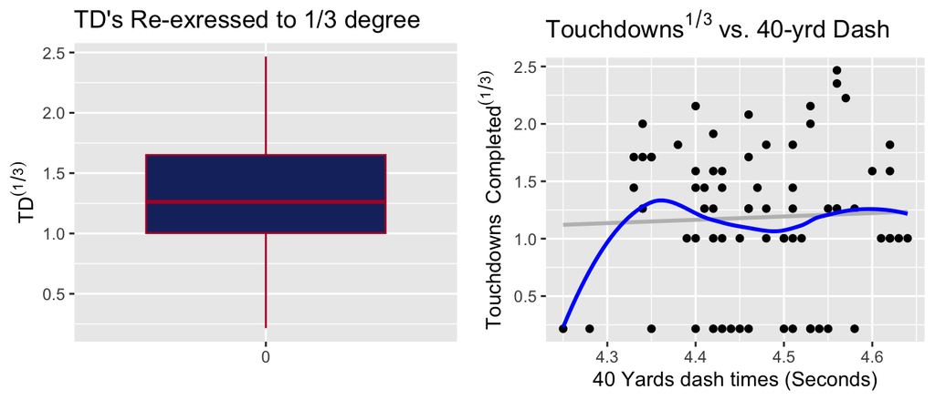

```r
# #Chunk 3
#Re-express data
WR_data_40TD <- WR_40 %>%
  mutate(TD_re = (TD_adj)^(1/3))

X3.1 <- ggplot(WR_data_40TD, aes(x = factor(0),y=TD_re)) + geom_boxplot(col="#B20032",fill="#192E6C") +
  ggtitle("TD's Re-exressed to 1/3 degree") +
  ylab(expression(TD^(1/3))) +
  xlab("")


X3.2 <- ggplot(WR_data_40TD, aes(X40yards , TD_re)) + geom_point() +
  stat_smooth(method = "lm", se=FALSE, formula = y ~ x,col="grey") +
  stat_smooth(method= "loess", se=FALSE, formula = y ~ x, col="blue") +
  ggtitle(expression(Touchdowns^{1/3} ~ "vs. 40-yrd Dash")) +
  ylab(expression(Touchdowns~~Completed^(1/3))) +
  xlab("40 Yards dash times (Seconds)")

grid.arrange(X3.1, X3.2, ncol = 2)
```

## Primary Analysis

The next best path to take is to see whether certain categories of wide receivers can be predicted by these same metrics. The first place of comparison I’d like to make is with player height. My question of focus is now whether 6 foot and above wide receivers indicate better league success in correlation to their combine metrics. After conducting initial tests, I observed that there was still no clear trend in 40 yard dash times and NFL success. As a result, I expanded my investigation onto the effect of all timed combine metrics on yards per game.

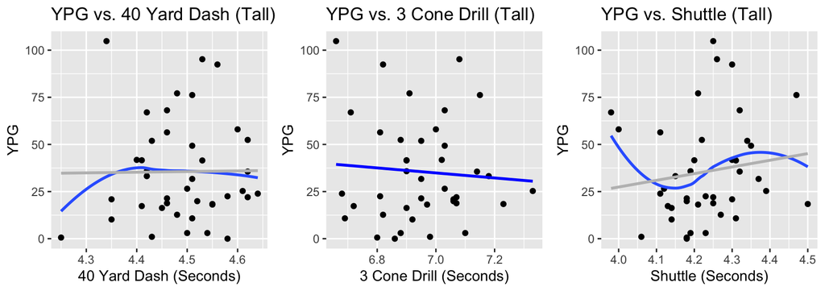

```r
#summary(WR_data$height)

WR_data_40tall <- WR_data_40TD %>%
  filter(height > 72 & !is.na(X3cone))


g4 <- ggplot(WR_data_40tall, aes(x=X40yards, y=YPG)) + geom_point() +
  stat_smooth(method= "loess", se=FALSE, formula = y ~ x, span=1) +
  stat_smooth(method= "lm", se=FALSE, formula = y ~ x, col="grey") +
  ggtitle("YPG vs. 40 Yard Dash (Tall)") + xlab("40 Yard Dash (Seconds)") + ylab("YPG")

g5 <- ggplot(WR_data_40tall, aes(x=X3cone, y=YPG)) + geom_point() +

  stat_smooth(method= "lm", se=FALSE, formula = y ~ x, col="blue") +
  ggtitle("YPG vs. 3 Cone Drill (Tall)") + xlab("3 Cone Drill (Seconds)") + ylab("YPG")


g6 <- ggplot(WR_data_40tall, aes(x=shuttle, y=YPG)) + geom_point() +
  stat_smooth(method= "loess", se=FALSE , formula = y ~ x, span=1) +
  stat_smooth(method= "lm", se=FALSE, formula = y ~ x, col="grey") +
  ggtitle("YPG vs. Shuttle (Tall)") + xlab("Shuttle (Seconds)") + ylab("YPG")


grid.arrange(g4, g5, g6, ncol = 3)
```